# JSC370 Midterm - A Look at NFL Field Goals in the 2018-2020 Seasons

Chloe Nguyen

23/02/2022

## Introduction

American football is one of the most watched sports in North America. In these games, one of the many ways to earn points is through a field goal- during which, a kicker attempts to kick the ball through the crossbar. In this report, we will examine the factors that contribute to a field goal kick. The question we are interested in exploring is: what variables are associated with the kicking length of a field goal and what is the relationship between kicking length and kicking attempt outcome?

The repo link for this project is: https://github.com/annguyen1404/JSC370-midterm

$$\\[0.1in]$$

## Methods

### The Datasets

The dataset we’ll be working with details all special team plays (that is, plays that involve punts, kickoffs, field goals and extra points) in all National Football League (NFL) games from 2018 to 2020. This dataset was provided by the NFL as a part of their 2022 data competition, Big Data Bowl: https://www.kaggle.com/c/nfl-big-data-bowl-2022/overview

We’ll also refer to this dataset for the locations of NFL teams’ home stadiums: https://github.com/Sinbad311/CloudProject/blob/master/NFL%20Stadium%20Latitude%20and%20Longtitude.csv

Additionally, we’ll use this dataset for the abbreviations of NFl teams: https://gist.github.com/cnizzardini/13d0a072adb35a0d5817

$$\\$$

### The Tools

We’ll use dplyr to help merge all datasets and also create new variables. Additionally, we’ll use ggplot to create all plots and leaflet for the map. We’ll also use broom to tidy all raw outputs and format all tables with kable. For loading in the image and coordinating the points of the football field plots, we’ll use jpeg and grid.

$$\\$$

### Data Wrangling

First, we merge the data of team abbreviations with team locations (longittude and lattitude) by teams. Note that there were NFL teams that changed their names throughout the years- such as the Washington Football Team who also went by the Washington Redskins. Hence, these names need to be modified to match for the datasets to be properly merged. Moreover, there were also teams that recently moved to a different location (e.g. Las Vegas Raiders) and thus, we need to update their location to match their current state. We will use external sources to check the new location of the team and input in this new value.

We also check that the merge was sucessful by looking at the number of observations in the newly merged data. There should be 32 observations- one for each of the 32 NFL teams.

Dimensions of Merged Dataset of NFL Team Abbreviations and Locations

| Number of Rows | Number of Columns |
| --- | --- |
| 32 | 12 |

We then merge this dataset of team abbreviations and locations with the games data set (provided by the NFL Data Bowl) by home team abbreviation to get the location of where each game was played. Once again, we have to fix team naming conventions so that they match up in order to merge the datasets. We check that this merge was successful by making sure that the number of observations in the original games dataset is equal to the number of observations in the newly merged dataset.

Number of Observations in Datasets

| Datasets | Number of Rows |
| --- | --- |
| Games | 764 |
| Merged | 764 |

Then, we merge this new dataset with the game plays dataset (provided by the NFL Data Bowl) by gameId. This gives us the game information and location of each game play. Again, we have to fix team naming conventions so that they match up in order to merge the datasets. We check that number of observations of game plays and the number of observations of the new dataset are equal to verify that the merge was successful.

Number of Observations in Datasets

| Datasets | Number of Rows |
| --- | --- |
| Game Plays | 19979 |
| Merged | 19979 |

In this analysis, we’ll only be examing field goals. Hence, we’ll filter for plays that are ‘Field Goal’.

Additionally, we merge this new dataset of field goal plays with a dataset of players (provided by the NFL Data Bowl) by kickerId to get more information on the athlete who kicked the ball in each game play. However, before the merge, we need to standardize entries in the players dataset.

Similar to before, to check that the merge was successful, we make sure that the number of observations in the newly merged dataset is equal to that of the dataset of field goal plays

Number of Observations in Datasets

| Datasets | Number of Rows |
| --- | --- |
| Field Goal Plays | 2657 |
| Merged | 2657 |

Now, we select the variables relevant to our question of interest: season, week, gameDate, gameTimeEastern, longitude, latitude, homeTeamAbbr, visitorTeamAbbr, quarter, down, specialTeamsPlayType, specialTeamsResult, possessionTeam, yardlineNumber, gameClock, kickLength, kickerId, height_cm, weight_kg, birthDate, displayName, collegeName, Position.

Finally, we create the following variables of interest:

- birthYear: The year that the player kicking the ball was born
- age: The age of the player at the time of kick
- specialTeamsSuccess: Whether or not the kick attempt was classified as “good”
- possessionTeamHome: Whether or not the team in posession of the ball is the home team

$$\\$$

### Exploring the Variables and Handling Missing Values

We first take a look at all the variables of the final dataset that we are working with, their types, whether they are numerical or categorical and the number of missing entires there are.

Overview of Variables

| Column | Type | Numerical or Categorical | Number of NAs |
| --- | --- | --- | --- |
| season | double | numerical | 0 |
| week | double | numerical | 0 |
| gameDate | character | numerical | 0 |
| gameTimeEastern | double | numerical | 0 |
| longitude | double | numerical | 0 |
| latitude | double | numerical | 0 |
| homeTeamAbbr | character | categorical | 0 |
| visitorTeamAbbr | character | categorical | 0 |
| quarter | double | numerical | 0 |
| down | double | numerical | 0 |
| specialTeamsPlayType | character | categorical | 0 |
| specialTeamsResult | character | categorical | 0 |
| possessionTeam | character | categorical | 0 |
| yardlineNumber | double | numerical | 0 |
| gameClock | double | numerical | 0 |
| kickLength | double | numerical | 51 |
| kickerId | double | numerical | 14 |
| height_cm | double | numerical | 14 |
| weight_kg | double | numerical | 14 |
| birthDate | double | numerical | 15 |
| displayName | character | categorical | 14 |
| collegeName | character | categorical | 15 |
| Position | character | categorical | 14 |
| birthYear | double | categorical | 15 |
| age | double | numerical | 15 |
| specialTeamsSuccess | logical | categorical | 0 |
| possessionTeamHome | logical | categorical | 0 |

After that, we impute missing values for relevant variables. Note that we use the mean for numerical values and the median for categorical values.

The dataset is now ready to be explored.

$$\\[0.1in]$$

## Preliminary Results

First, to get a sense of from where kick attempts were made, we visualise the yard line of the line-of-scrimmage (i.e. the line where the play starts) of field goal attempts in the 2018-2020 seasons. From the plot we see that most attempts were roughly from the 20 yard line. Additionally, we also discover that the number of field goal attempts significantly drops at around the 40 yard line and further.

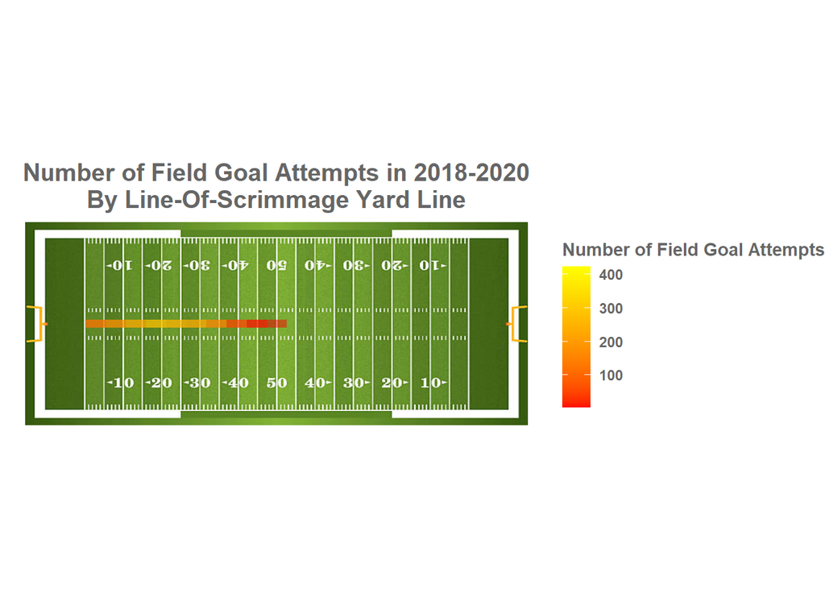

Next we take a look at the proportion of successful kicks at various line-of-scrimmage yard lines. We see that the success proportion is quite consistent for attempts at roughly the 47 yard line and under. However for field goal attempts over 47 yards, the success drops significantly. Most kicks at these yard lines are unsuccessful.

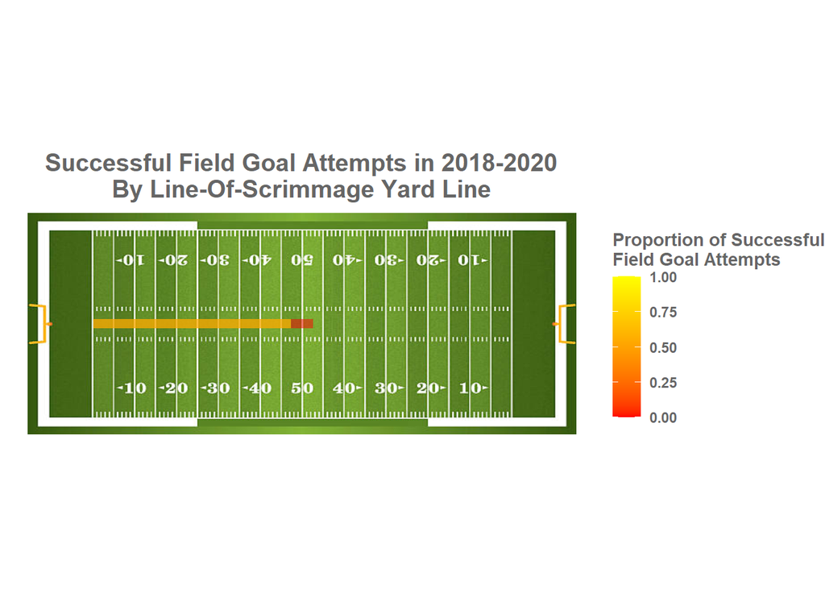

$$\\$$

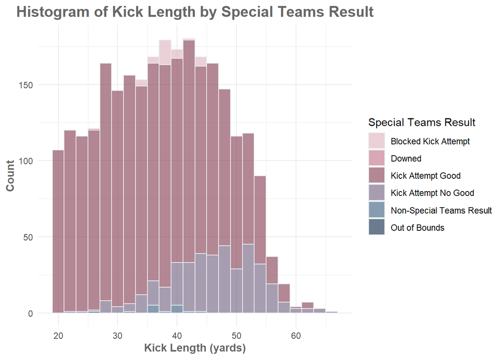

Investigating further, we create a summary table for kick length by special teams results. From this, we can see that indeed the mean of a “no good” kick or an unsuccessful kick (46.52 yards) is higher than that of a “good” kick or a successful kick (36.70). Moreover, the overall minimum kicking length was 19 yards and it was a successful kick; while the overall maximum kicking length attempt was 67 yards and was unsuccessful. We also note that there was only 1 downed kick and 1 out of bounds kick in all of the 2018-2020 seasons.

Summary of Kick Length by Special Team Result

| Special Teams Result | Min Kick Length | Max Kick Length | Mean Kick Length | Standard Deviation of Kick Length | Range of Kick Length |
| --- | --- | --- | --- | --- | --- |
| Blocked Kick Attempt | 33.27 | 43.25 | 38.57 | 2.79 | 9.98 |
| Downed | 26.00 | 26.00 | 26.00 | NA | 0.00 |
| Kick Attempt Good | 19.00 | 63.00 | 36.70 | 9.75 | 44.00 |
| Kick Attempt No Good | 22.00 | 67.00 | 46.52 | 7.60 | 45.00 |
| Non-Special Teams Result | 32.61 | 43.25 | 38.02 | 2.74 | 10.64 |
| Out of Bounds | 26.00 | 26.00 | 26.00 | NA | 0.00 |

$$\\$$

Now, we explore the kicking length by NFL teams in the 2018-2020 season. From the boxplot, we see that the Denver Broncos (DEN) and Tennessee Titans (TEN) had the highest average kicking lengths at roughly 42 yards. The team with the lowest average kick length is the Las Vegas Raiders (LV) at roughly 35 yards.

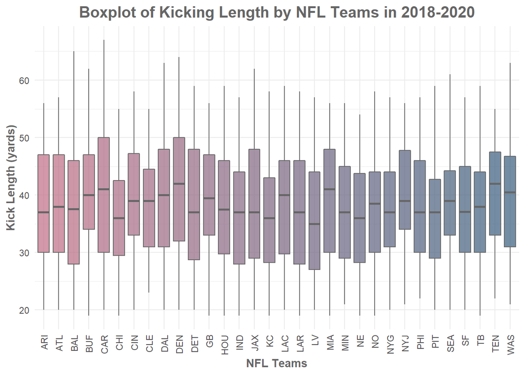

$$\\$$

Perhaps kickers who are taller and have longer legs would be able to kick further lengths? On that train of thought, we examine the plots of kick length vs. kicker height for successful and unsuccessul kicks. We see that for both kick results, the linear regression line is almost completely flat and the points do not follow a particular pattern. Hence, there is essentially no association between these a kicker’s height and their kick length- whether the kick is successful or unsuccessful.

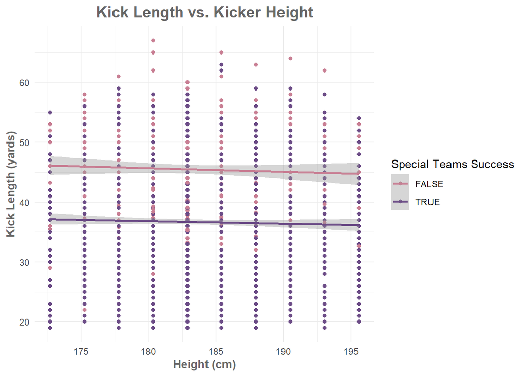

$$\\$$

Maybe kickers with more mass would have more power and would be able to kick longer lengths? With our data, we plot kick length vs. kicker weight for successful and unsuccessul kicks. From this, we also see that for both kick results, the linear regression line is almost completely flat and the points do not follow a particular pattern. Thus, there is no association between these a kicker’s weight and their kick length- whether the kick is successful or unsuccessful.

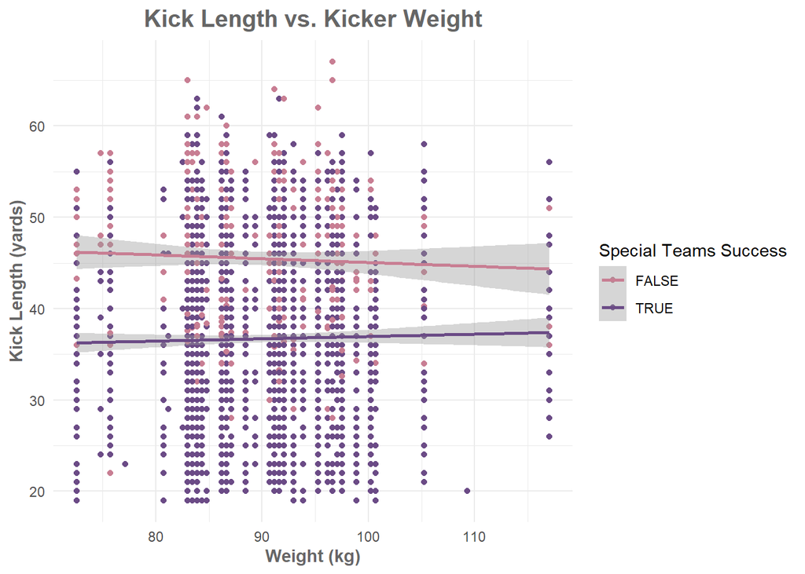

$$\\$$

Next, we visualize the teams and their home stadiums on a map.

[interactive chart not shown]

$$\\$$

From examing the locations of the various team stadiums, we are interested in determining whether there’s a change in average kick distance between plays in stadiums of high and low altitudes. In theory, high altitudes allows for better football performance since air pressure is lower and hence, the ball moves faster and straighter.

We use external resources to find the top 3 teams with stadiums at the highest and lowest altitudes:

- Highest altitudes: Denver Broncos (DEN), Arizona Cardinals (ARI), Atlanta Falcons (ATL)
- Lowest altitdues: New Orleans Saints (NO), New York Giants (NYG), New York Jets (NYJ)

Then, we filter for two groups: one with kicks from the top 3 highest altitude stadiums and one with kicks from the top 3 lowest altitude stadiums. Using a Mann–Whitney U test (otherwise known as a Wilcoxon 2-sample t-test), we check if there’s a significant difference in kick lengths between these two independent groups.

Mann–Whitney U test

| Statistic | P-Value | Method | Alternative |
| --- | --- | --- | --- |
| 270 | 0.10 | Wilcoxon rank sum test with continuity correction | Two sided |

With a p-value of 0.10, there is very weak evidence supporting the alternative hypothesis that there’s a significant difference in kick lengths between kicks in high altitude stadiums and kicks in low altitude stadiums.

$$\\$$

### The Models

To begin, we group our data of game plays by posessionTeam (the team that is kicking the ball) and season. In the process, we summarise to find:

- success_prop: the proportion of successful kick attempts
- avg_height: the average height of the kicker
- avg_weight: the average weight of the kicker
- avg_age: the average age (at time of kick) of the kicker
- home_prop: the proportion of these kicks that were done during a home game
- avg_kickLength: the average kick length in yards

To evaluate the relationship between kick length and successful kicking attempts and to explore the association of other factors in a successful kick, we will fit 2 models to this grouped data. The first model is a multiple linear regression (MLR) model for success_prop with predictors: avg_height, avg_weight, avg_age, home_prop and avg_kickLength. The second model uses cubic regression spline and only takes into account avg_kickLength.

$$\\$$

#### Summary of Multiple Linear Regression Model

Model Summary - MLR

| Term | Estimate | Standard Error | Statistic | P-Value |
| --- | --- | --- | --- | --- |
| (Intercept) | 1.2702291 | 0.4141791 | 3.0668593 | 0.0028568 |
| avg_height | 0.0008818 | 0.0020613 | 0.4277914 | 0.6698249 |
| avg_weight | -0.0005374 | 0.0015876 | -0.3384663 | 0.7358001 |
| avg_age | 0.0019038 | 0.0021033 | 0.9051547 | 0.3678002 |
| home_prop | -0.0910345 | 0.1036266 | -0.8784859 | 0.3820194 |
| avg_kickLength | -0.0147412 | 0.0042345 | -3.4811840 | 0.0007722 |

Model Summary - R Squared and Adjusted R Squared

| R Squared | Adjusted R Squared |
| --- | --- |
| 0.1307529 | 0.0824614 |

[figure not shown]

With an adjusted $R^2$ value of 0.08246, approximately 8.246% of variation in season success proportion can be explained by average height, average weight, average age, proportion of home games played and average kick length.

$$\\$$

#### Summary of Model with Cubic Regression Spline

Model Summary - Parametric Coefficients

| Estimate | Standard Error | T Value | P-Value |
| --- | --- | --- | --- |
| 0.8305724 | 0.008637 | 96.16419 | 0 |

Model Summary - Smooth Terms

| Term | Estimated Degree of Freedom | Reference Degree of Freedom | Statistic | P-Value |
| --- | --- | --- | --- | --- |
| s(avg_kickLength) | 5.188174 | 6.181432 | 4.665201 | 0.0003207 |

Model Summary - Adjusted R Squared and Deviance Explained

| Adjusted R Squared | Deviance Explained |
| --- | --- |
| 0.220824 | 0.2633766 |

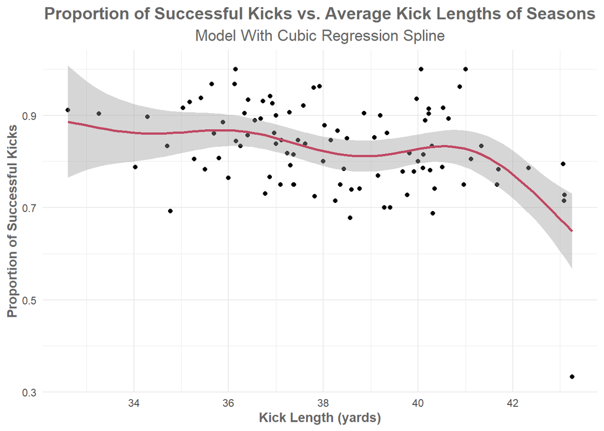

In this model, kick length is our smooth term. The associated p-value is 0.000321 and hence, it’s statistically significant. From the summary, the effective degree of freedom is 5.188 and thus, the curve of kick length is slightly more complex than a quintic curve. Moreover, the intercept has a p-value of less than $2 \times 10^{-16}$ and hence, it’s also statistically significant.

With an adjusted $R^2$ value of 0.221, roughly 22.1% of the data fit the model with cubic regression spline. This adjusted $R^2$ value is higher than that of the MLR model. Hence, this model is a better fit for the data.

$$\\[0.1in]$$

$$\\[0.5in]$$